# White Wine Analysis by Adarsh

```r
# Load the Data
setwd('~/Desktop/iPythonNotebook//DAND_P4/')
getwd()
```

```
## [1] "/Users/adarshnair/Desktop/iPythonNotebook/DAND_P4"
```

```r
wv <- read.csv('wineQualityWhites.csv')
str(wv)
```

```
## 'data.frame':    4898 obs. of  13 variables:
##  $ X                   : int  1 2 3 4 5 6 7 8 9 10 ...
##  $ fixed.acidity       : num  7 6.3 8.1 7.2 7.2 8.1 6.2 7 6.3 8.1 ...
##  $ volatile.acidity    : num  0.27 0.3 0.28 0.23 0.23 0.28 0.32 0.27 0.3 0.22 ...
##  $ citric.acid         : num  0.36 0.34 0.4 0.32 0.32 0.4 0.16 0.36 0.34 0.43 ...
##  $ residual.sugar      : num  20.7 1.6 6.9 8.5 8.5 6.9 7 20.7 1.6 1.5 ...
##  $ chlorides           : num  0.045 0.049 0.05 0.058 0.058 0.05 0.045 0.045 0.049 0.044 ...
##  $ free.sulfur.dioxide : num  45 14 30 47 47 30 30 45 14 28 ...
##  $ total.sulfur.dioxide: num  170 132 97 186 186 97 136 170 132 129 ...
##  $ density             : num  1.001 0.994 0.995 0.996 0.996 ...
##  $ pH                  : num  3 3.3 3.26 3.19 3.19 3.26 3.18 3 3.3 3.22 ...
##  $ sulphates           : num  0.45 0.49 0.44 0.4 0.4 0.44 0.47 0.45 0.49 0.45 ...
##  $ alcohol             : num  8.8 9.5 10.1 9.9 9.9 10.1 9.6 8.8 9.5 11 ...
##  $ quality             : int  6 6 6 6 6 6 6 6 6 6 ...
```

```r
summary(wv)
```

```
##        X        fixed.acidity    volatile.acidity  citric.acid
##  Min.   :   1   Min.   : 3.800   Min.   :0.0800   Min.   :0.0000
##  1st Qu.:1225   1st Qu.: 6.300   1st Qu.:0.2100   1st Qu.:0.2700
##  Median :2450   Median : 6.800   Median :0.2600   Median :0.3200
##  Mean   :2450   Mean   : 6.855   Mean   :0.2782   Mean   :0.3342
##  3rd Qu.:3674   3rd Qu.: 7.300   3rd Qu.:0.3200   3rd Qu.:0.3900
##  Max.   :4898   Max.   :14.200   Max.   :1.1000   Max.   :1.6600
##  residual.sugar     chlorides       free.sulfur.dioxide
##  Min.   : 0.600   Min.   :0.00900   Min.   :  2.00
##  1st Qu.: 1.700   1st Qu.:0.03600   1st Qu.: 23.00
##  Median : 5.200   Median :0.04300   Median : 34.00
##  Mean   : 6.391   Mean   :0.04577   Mean   : 35.31
##  3rd Qu.: 9.900   3rd Qu.:0.05000   3rd Qu.: 46.00
##  Max.   :65.800   Max.   :0.34600   Max.   :289.00
##  total.sulfur.dioxide    density             pH          sulphates
##  Min.   :  9.0        Min.   :0.9871   Min.   :2.720   Min.   :0.2200
##  1st Qu.:108.0        1st Qu.:0.9917   1st Qu.:3.090   1st Qu.:0.4100
##  Median :134.0        Median :0.9937   Median :3.180   Median :0.4700
##  Mean   :138.4        Mean   :0.9940   Mean   :3.188   Mean   :0.4898
##  3rd Qu.:167.0        3rd Qu.:0.9961   3rd Qu.:3.280   3rd Qu.:0.5500
##  Max.   :440.0        Max.   :1.0390   Max.   :3.820   Max.   :1.0800
##     alcohol         quality
##  Min.   : 8.00   Min.   :3.000
##  1st Qu.: 9.50   1st Qu.:5.000
##  Median :10.40   Median :6.000
##  Mean   :10.51   Mean   :5.878
##  3rd Qu.:11.40   3rd Qu.:6.000
##  Max.   :14.20   Max.   :9.000
```

```r
# There are 4898 observations with 12 features. Descriptions of the features can be found here - https://s3.amazonaws.com/udacity-hosted-downloads/ud651/wineQualityInfo.txt
```

I am interested in analysing the Quality variable which has a scale of 0-10 with 10 being the highest quality white wine. The quality of wines in this dataset have a range of [3,9] with mean value of 5.878 and median of 6. I will factor the quality variable.

```
wv$quality <- factor(wv$quality, ordered = T)
table(wv$quality)
```

```
grid.arrange(qplot(wv$fixed.acidity),
             qplot(wv$volatile.acidity),
             qplot(wv$citric.acid),
             qplot(wv$residual.sugar),
             qplot(wv$chlorides),
             qplot(wv$free.sulfur.dioxide),
             qplot(wv$total.sulfur.dioxide),
             qplot(wv$density),
             qplot(wv$pH),
             qplot(wv$sulphates),
             qplot(wv$alcohol),
             qplot(wv$quality),
             ncol = 5)
```

```
grid.arrange(qplot(x = 'Fixed Acidity',
                   y = wv$fixed.acidity,
                   data = wv,
                   geom = 'boxplot'),
             qplot(x = 'Volatile Acidity',
                   y = wv$volatile.acidity,
                   data = wv,
                   geom = 'boxplot'),
             qplot(x = 'Citric Acid',
                   y = wv$citric.acid,
                   data = wv,
                   geom = 'boxplot'),
             qplot(x = 'Residual Sugar',
                   y = wv$residual.sugar,
                   data = wv,
                   geom = 'boxplot'),
             qplot(x = 'Chlorides',
                   y = wv$chlorides,
                   data = wv,
                   geom = 'boxplot'),
             qplot(x = 'Free Sulfur Dioxide',
                   y = wv$free.sulfur.dioxide,
                   data = wv,
                   geom = 'boxplot'),
             qplot(x = 'Total Sulfur Dioxide',
                   y = wv$total.sulfur.dioxide,
                   data = wv,
                   geom = 'boxplot'),
             qplot(x = 'Density',
                   y = wv$density,
                   data = wv,
                   geom = 'boxplot'),
             qplot(x = 'pH',
                   y = wv$pH,
                   data = wv,
                   geom = 'boxplot'),
             qplot(x = 'Sulphates',
                   y = wv$sulphates,
                   data = wv,
                   geom = 'boxplot'),
             qplot(x = 'Alcohol',
                   y = wv$alcohol,
                   data = wv,
                   geom = 'boxplot'),
             qplot(x = 'Quality',
                   y = wv$quality,
                   data = wv,
                   geom = 'boxplot'),
             ncol = 5)
```

# Univariate Plots Section

```r
# New quality rating

wv$rating <- ifelse(wv$quality > 7, 'Good', ifelse(wv$quality <= 4, 'Mediocre', 'Average'))

# Order the ratings

wv$rating <- ordered(wv$rating, levels = c('Mediocre', 'Average', 'Good'))

# Summary of the ratings variable

summary(wv$rating)
```

```
## Mediocre  Average     Good
##      183     4535      180
```

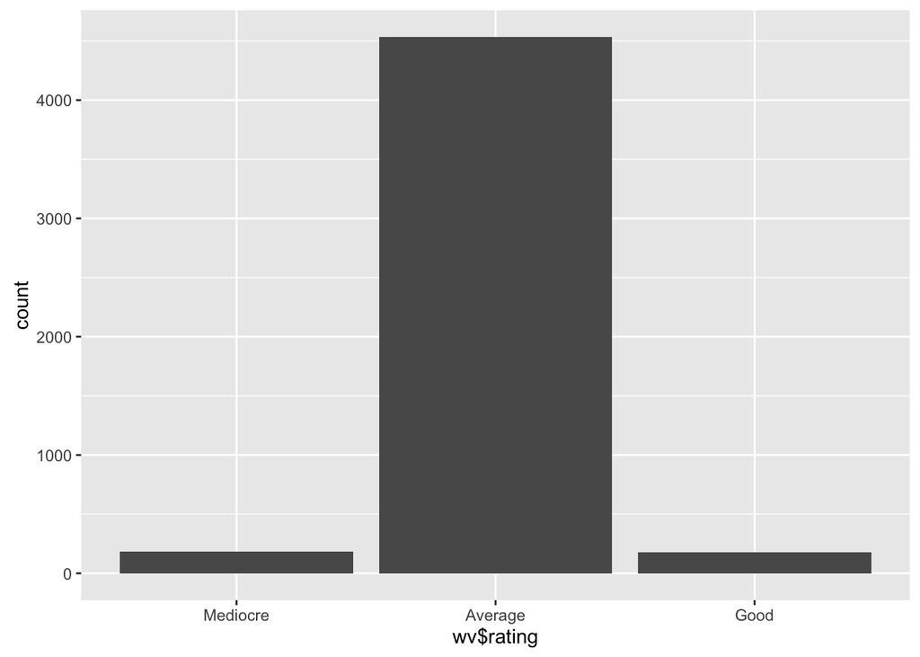

```r
# Visualizationg of the wine rating categories.

ggplot(aes(wv$rating),
       data = wv) +
  geom_bar()
```

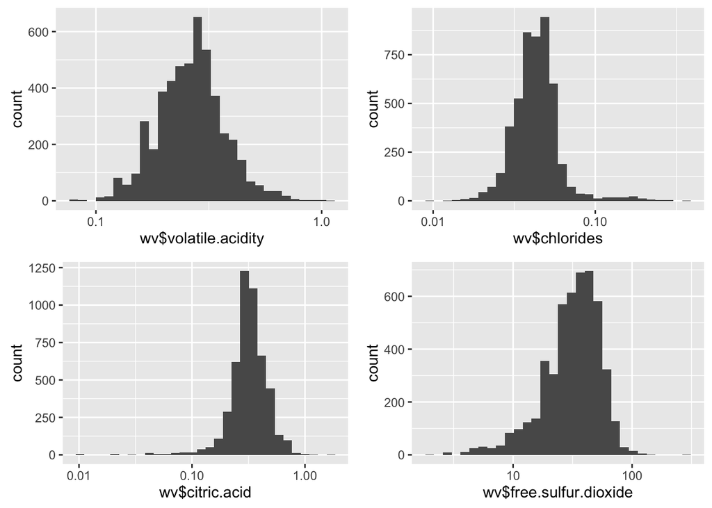

```r
# Scaling of Volatile Acidity, Citric Acid, Chlorides and Free Sulfur Dioxide to their log values.

grid.arrange(ggplot(aes(wv$volatile.acidity),data = wv) +
               geom_histogram() + scale_x_log10(),
             ggplot(aes(wv$chlorides),data = wv) +
               geom_histogram() + scale_x_log10(),
             ggplot(aes(wv$citric.acid),data = wv) +
               geom_histogram() + scale_x_log10(),
             ggplot(aes(wv$free.sulfur.dioxide),data = wv) +
               geom_histogram() + scale_x_log10(),
             ncol = 2)
```

# Univariate Analysis

### What is the structure of your dataset?

There are 4898 observations with 12 features. The features are: fixed.acidity, volatile.acidity, citric.acid, residual.sugar, chlorides, free.sulfur.dioxide, total.sulfur.dioxide, density, pH, sulphates, alcohol and quality. The description of the attributes is as follows: Description of attributes:

1 - fixed acidity: most acids involved with wine or fixed or nonvolatile (do not evaporate readily)

2 - volatile acidity: the amount of acetic acid in wine, which at too high of levels can lead to an unpleasant, vinegar taste

3 - citric acid: found in small quantities, citric acid can add ‘freshness’ and flavor to wines

4 - residual sugar: the amount of sugar remaining after fermentation stops, it’s rare to find wines with less than 1 gram/liter and wines with greater than 45 grams/liter are considered sweet

5 - chlorides: the amount of salt in the wine

6 - free sulfur dioxide: the free form of SO2 exists in equilibrium between molecular SO2 (as a dissolved gas) and bisulfite ion; it prevents microbial growth and the oxidation of wine

7 - total sulfur dioxide: amount of free and bound forms of S02; in low concentrations, SO2 is mostly undetectable in wine, but at free SO2 concentrations over 50 ppm, SO2 becomes evident in the nose and taste of wine

8 - density: the density of water is close to that of water depending on the percent alcohol and sugar content

9 - pH: describes how acidic or basic a wine is on a scale from 0 (very acidic) to 14 (very basic); most wines are between 3-4 on the pH scale

10 - sulphates: a wine additive which can contribute to sulfur dioxide gas (S02) levels, which acts as an antimicrobial and antioxidant

11 - alcohol: the percent alcohol content of the wine

Output variable (based on sensory data): 12 - quality (score between 0 and 10)

### Did you create any new variables from existing variables in the dataset?

To better understand the rating of the quality of the wine, I have classified the wine ratings into three categories: 0-4 is ‘Mediocre’, 5-7 is ‘Average’ and 8-9 is ‘Good’. I have used the official wine 100 point rating scale as inspiration. Based on that metric we have 183 Mediocre, 4535 Average and 180 Good category wines.

### Of the features you investigated, were there any unusual distributions? Did you perform any operations on the data to tidy, adjust, or change the form of the data? If so, why did you do this?

To get a better scale on the values of Volatile Acidity, Citric Acid, Chlorides and Free Sulfur Dioxide, I converted them to their log values.

# Bivariate Plots Section

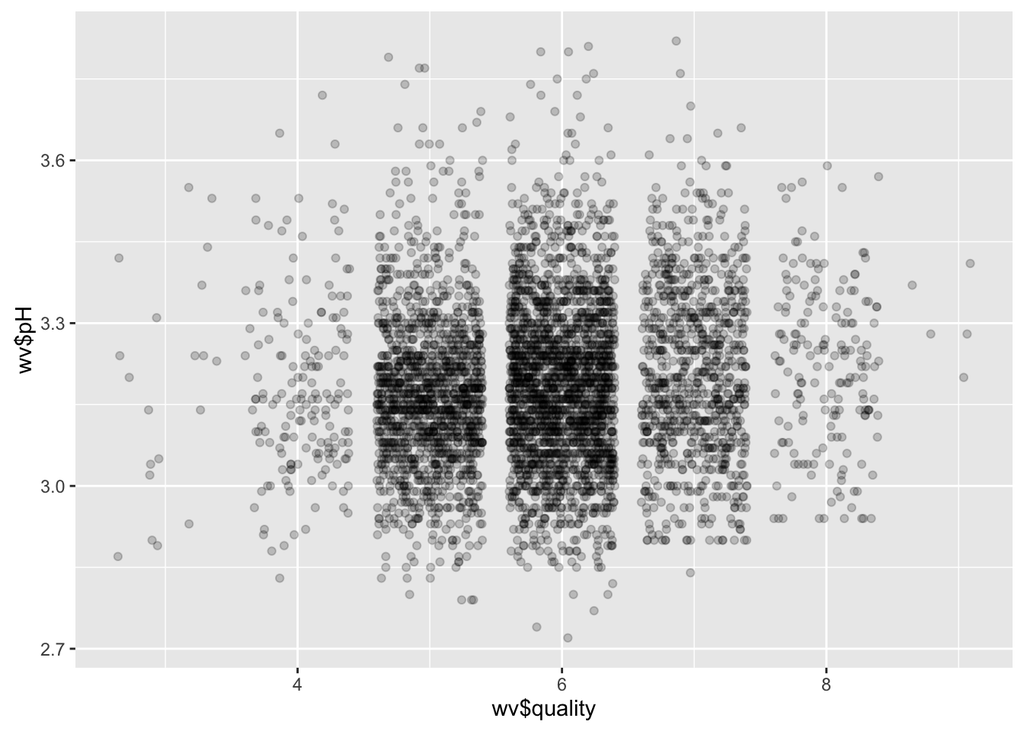

```r
# Exploring the relationship between Quality and pH

ggplot(aes(x = wv$quality, y = wv$pH),
       data = wv) +
  geom_point(alpha = 1/5, position = position_jitter(h = 0))
```

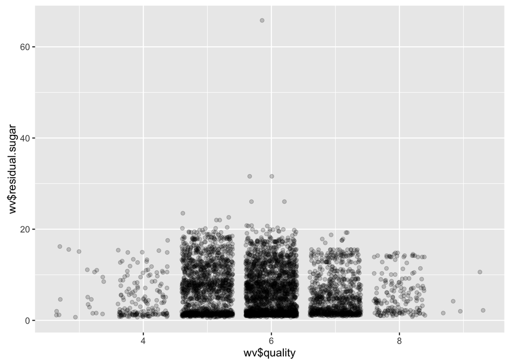

```r
# Exploring the relationship between Quality and Sweetness

ggplot(aes(x = wv$quality, y = wv$residual.sugar),
       data = wv) +
  geom_point(alpha = 1/5, position = position_jitter(h = 0))
```

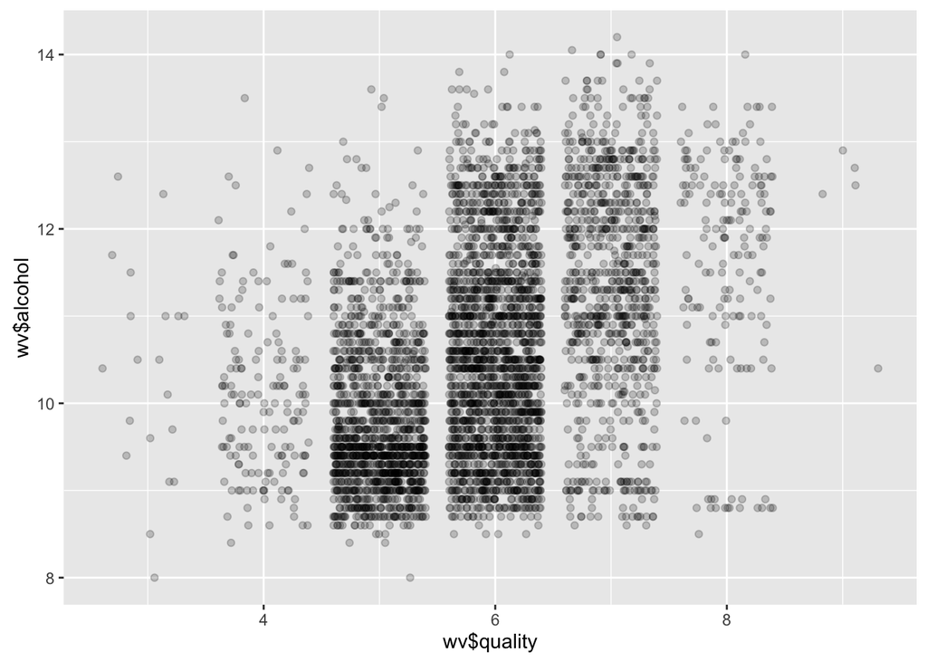

```r
# Exploring the relationship between Quality and Alcohol

ggplot(aes(x = wv$quality, y = wv$alcohol),
       data = wv) +
  geom_point(alpha = 1/5, position = position_jitter(h = 0))
```

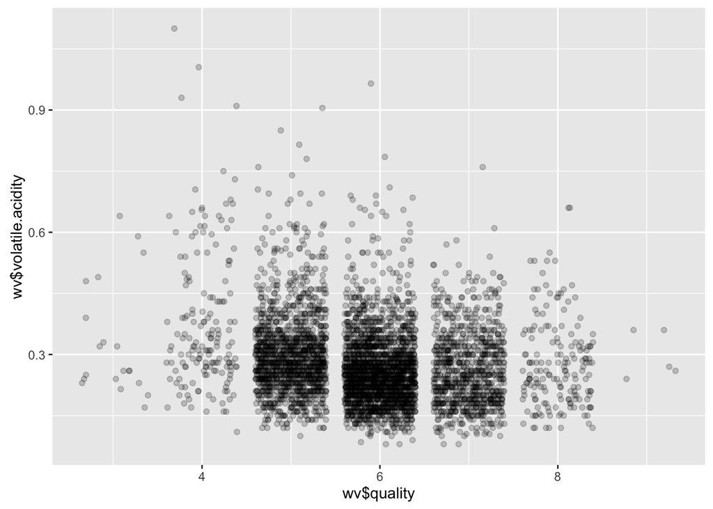

```r
# Exploring the relationship between Quality and Volatile Acidity

ggplot(aes(x = wv$quality, y = wv$volatile.acidity),
       data = wv) +
  geom_point(alpha = 1/5, position = position_jitter(h = 0))
```

Exploring the correlation values between Quality and our other features

```
with(wv, cor.test(as.numeric(quality), as.numeric(pH), method = 'pearson'))
with(wv, cor.test(as.numeric(quality), as.numeric(volatile.acidity), method = 'pearson'))
with(wv, cor.test(as.numeric(quality), as.numeric(residual.sugar), method = 'pearson'))
with(wv, cor.test(as.numeric(quality), as.numeric(chlorides), method = 'pearson'))
with(wv, cor.test(as.numeric(quality), as.numeric(citric.acid), method = 'pearson'))
with(wv, cor.test(as.numeric(quality), as.numeric(density), method = 'pearson'))
with(wv, cor.test(as.numeric(quality), as.numeric(sulphates), method = 'pearson'))
with(wv, cor.test(as.numeric(quality), as.numeric(total.sulfur.dioxide), method = 'pearson'))
with(wv, cor.test(as.numeric(quality), as.numeric(free.sulfur.dioxide), method = 'pearson'))
with(wv, cor.test(as.numeric(quality), as.numeric(fixed.acidity), method = 'pearson'))
with(wv, cor.test(as.numeric(quality), as.numeric(alcohol), method = 'pearson'))
```

```
ggplot(aes(x = quality, y = alcohol, group =1),
       data = wv) +
      geom_point(alpha = 1/5,
                 position = position_jitter(h = 0),
                 color = 'orange') +
  coord_trans(y = 'log10') +
  #coord_cartesian(xlim = c(4,8)) +
  geom_line(stat = 'summary', fun.y = mean) +
  #generate the 10% quantile on the plot, 10% of wines have alcohol counts below this line
  geom_line(stat = 'summary', fun.y = quantile, fun.args=list(probs=0.1), linetype = 2, color = 'blue') +
  #90% of wine have alcohol below this line
  geom_line(stat = 'summary', fun.y = quantile, fun.args=list(probs=0.9), linetype = 2, color = 'red') +
  #50% of wine have alcohol counts below this line
  geom_line(stat = 'summary', fun.y = quantile, fun.args=list(probs=0.5), linetype = 2, color = 'green')


ggplot(aes(x = quality, y = density, group =1),
       data = wv) +
      geom_point(alpha = 1/5,
                 position = position_jitter(h = 0),
                 color = 'orange') +
  coord_trans(y = 'log10') +
  #coord_cartesian(ylim = c(0,12)) +
  geom_line(stat = 'summary', fun.y = mean) +
  #generate the 10% quantile on the plot, 10% of wines have density counts below this line
  geom_line(stat = 'summary', fun.y = quantile, fun.args=list(probs=0.1), linetype = 2, color = 'blue') +
  #90% of wine have density below this line
  geom_line(stat = 'summary', fun.y = quantile, fun.args=list(probs=0.9), linetype = 2, color = 'red') +
  #50% of wine have density counts below this line
  geom_line(stat = 'summary', fun.y = quantile, fun.args=list(probs=0.5), linetype = 2, color = 'green')


ggplot(aes(x = quality, y = chlorides, group =1),
       data = wv) +
      geom_point(alpha = 1/5,
                 position = position_jitter(h = 0),
                 color = 'orange') +
  coord_trans(y = 'log10') +
  #coord_cartesian(xlim = c(4,8)) +
  geom_line(stat = 'summary', fun.y = mean) +
  #generate the 10% quantile on the plot, 10% of wines have chloride counts below this line
  geom_line(stat = 'summary', fun.y = quantile, fun.args=list(probs=0.1), linetype = 2, color = 'blue') +
  #90% of wine have chloride counts below this line
  geom_line(stat = 'summary', fun.y = quantile, fun.args=list(probs=0.9), linetype = 2, color = 'red') +
  #50% of wine have chloride counts below this line
  geom_line(stat = 'summary', fun.y = quantile, fun.args=list(probs=0.5), linetype = 2, color = 'green')
```

Based on the our predisposition to quality metrics, we analyse pH and residual.sugar

```
ggplot(aes(x = quality, y = pH, group =1),
       data = wv) +
      geom_point(alpha = 1/5,
                 position = position_jitter(h = 0),
                 color = 'orange') +
  coord_trans(y = 'log10') +
  #coord_cartesian(xlim = c(4,8)) +
  geom_line(stat = 'summary', fun.y = mean) +
  #generate the 10% quantile on the plot, 10% of wines have pH counts below this line
  geom_line(stat = 'summary', fun.y = quantile, fun.args=list(probs=0.1), linetype = 2, color = 'blue') +
  #90% of wine have pH counts below this line
  geom_line(stat = 'summary', fun.y = quantile, fun.args=list(probs=0.9), linetype = 2, color = 'red') +
  #50% of wine have pH counts below this line
  geom_line(stat = 'summary', fun.y = quantile, fun.args=list(probs=0.5), linetype = 2, color = 'green')

ggplot(aes(x = quality, y = residual.sugar, group =1),
       data = wv) +
      geom_point(alpha = 1/5,
                 position = position_jitter(h = 0),
                 color = 'orange') +
  coord_trans(y = 'log10') +
  #coord_cartesian(xlim = c(4,8)) +
  geom_line(stat = 'summary', fun.y = mean) +
  #generate the 10% quantile on the plot, 10% of wines have sugar counts below this line
  geom_line(stat = 'summary', fun.y = quantile, fun.args=list(probs=0.1), linetype = 2, color = 'blue') +
  #90% of wine have sugar counts below this line
  geom_line(stat = 'summary', fun.y = quantile, fun.args=list(probs=0.9), linetype = 2, color = 'red') +
  #50% of wine have sugar counts below this line
  geom_line(stat = 'summary', fun.y = quantile, fun.args=list(probs=0.5), linetype = 2, color = 'green')
```

### Analyse relationships between features that are not our primary features

Fixed acidity and Volatile acidity:

```
ggplot(aes(x = fixed.acidity, y = volatile.acidity), data = wv) +
  geom_point()
```

Analyse the r score:

```
with(wv, cor.test(as.numeric(fixed.acidity), as.numeric(volatile.acidity), method = 'pearson'))
```

Graph of Fixed acidity and citric acid

```
ggplot(aes(x = fixed.acidity, y = citric.acid), data = wv) +
  geom_point()
```

analyse the r score

```
with(wv, cor.test(as.numeric(fixed.acidity), as.numeric(citric.acid), method = 'pearson'))
```

Volatile acidity and citric acid

```
ggplot(aes(x = volatile.acidity, y = citric.acid), data = wv) +
  geom_point()
```

analyse the r score

```
with(wv, cor.test(as.numeric(volatile.acidity), as.numeric(citric.acid), method = 'pearson'))
```

# Free sulfur dioxide and total sulfur dioxide

```
ggplot(aes(x = free.sulfur.dioxide, y = total.sulfur.dioxide), data = wv) +
  geom_point()
```

analyse the r score

```
with(wv, cor.test(as.numeric(free.sulfur.dioxide), as.numeric(total.sulfur.dioxide), method = 'pearson'))
```

Fixed acidity and pH

```
ggplot(aes(x = fixed.acidity, y = pH), data = wv) +
  geom_point()
```

analyse the r score

```
with(wv, cor.test(as.numeric(fixed.acidity), as.numeric(pH), method = 'pearson'))
```

Volatile acidity and pH

```
ggplot(aes(x = volatile.acidity, y = pH), data = wv) +
  geom_point()
```

analyse the r score

```
with(wv, cor.test(as.numeric(volatile.acidity), as.numeric(pH), method = 'pearson'))
```

Computer r score with normalised data

```
with(wv, cor.test(as.numeric(quality), log10(as.numeric(pH)), method = 'pearson'))
with(wv, cor.test(as.numeric(quality), log10(as.numeric(volatile.acidity)), method = 'pearson'))
with(wv, cor.test(as.numeric(quality), log10(as.numeric(residual.sugar)), method = 'pearson'))
with(wv, cor.test(as.numeric(quality), log10(as.numeric(chlorides)), method = 'pearson'))
with(wv, cor.test(as.numeric(quality), log10(as.numeric(citric.acid)), method = 'pearson'))
with(wv, cor.test(as.numeric(quality), log10(as.numeric(density)), method = 'pearson'))
with(wv, cor.test(as.numeric(quality), log10(as.numeric(sulphates)), method = 'pearson'))
with(wv, cor.test(as.numeric(quality), log10(as.numeric(total.sulfur.dioxide)), method = 'pearson'))
with(wv, cor.test(as.numeric(quality), log10(as.numeric(free.sulfur.dioxide)), method = 'pearson'))
with(wv, cor.test(as.numeric(quality), log10(as.numeric(fixed.acidity)), method = 'pearson'))
with(wv, cor.test(as.numeric(quality), log10(as.numeric(alcohol)), method = 'pearson'))
```

# Bivariate Analysis

### Talk about some of the relationships you observed in this part of the investigation. How did the feature(s) of interest vary with other features in the dataset?

The acidity(wv$pH), sweetness(wv$residual.sugar), alcohol content(wv$alcohol) are the main driving factors to understanding and assessing the quality of wine. The correlation scores I obtained are as follows:

Features of interest: pH: 0.099 residual.sugar: -0.097 alcohol: 0.436

Other features: volatile.acidity: -0.194723 fixed.acidity: -0.1136628 chlorides: -0.2099344 citric.acid: -0.009209091 density: -0.3071233 sulphates: 0.05367788 total.sulfur.dioxide: -0.1747372 free.sulfur.dioxide: 0.008158067

Correlation is an effect size and so we can verbally describe the strength of the correlation using the guide that Evans (1996)(http://www.statstutor.ac.uk/resources/uploaded/pearsons.pdf) suggests for the absolute value of r: .00-.19 “very weak” .20-.39 “weak” .40-.59 “moderate” .60-.79 “strong” .80-1.0 “very strong”

### What was the strongest relationship you found?

The strongest relationships to quality were:

Alcohol: 43.6% Density: -30.7% Chlorides(log10): -27.2% Volatile Acidity: -19.4% Total Sulfur Dioxide: -17.4% Fixed Acidity: -11.3%

# Multivariate Plots Section

Analysis of quality with alcohol content and density

```
ggplot(aes(x = alcohol, y = density, color = quality),
       data = wv) +
  geom_point() +
  facet_wrap(~rating)
```

Analysis of quality with pH and residual sugar

```
ggplot(aes(x = pH, y = residual.sugar, color = quality),
       data = wv) +
  geom_point() +
  facet_wrap(~rating)
```

# Analysis of quality with alcohol content and residual sugar

```
ggplot(aes(x = alcohol, y = residual.sugar),
       data = subset(wv, !is.na(pH))) +
  geom_line(aes(color = rating),
            stat = 'summary',
            fun.y = mean) +
  facet_wrap(~rating)
```

Analysis of quality with sulphates and density

```
ggplot(aes(x = sulphates, y = density, color = quality),
       data = wv) +
  geom_point() +
  facet_wrap(~rating)
```

Analysis of quality with total.sulfur.dioxide and fixed.acidity

```
ggplot(aes(x = total.sulfur.dioxide, y = fixed.acidity, color = quality),
       data = wv) +
  geom_point() +
  facet_wrap(~rating)
```

# Multivariate Analysis

### Were there any interesting or surprising interactions between features?

I ran some tests to check if our other predispositioned features, pH and residual sugars could give us some insight. But upon generating those graphs and facet wrapping with our new variable ‘rating’, it was still hard to say if these features were significant contributing factors.

# Final Plots and Summary

### Plot One

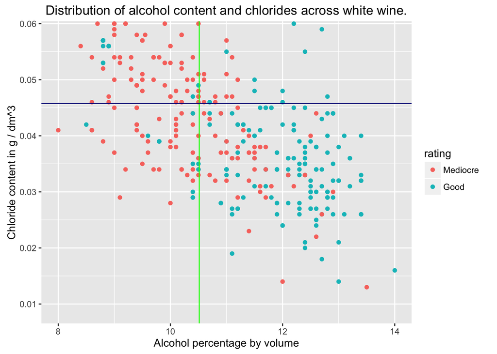

```r
#Alcohol and Chlorides

ggplot(aes(x = alcohol, y = chlorides, color = rating),
       data = subset(wv, rating != "Average")) +
   coord_cartesian(xlim = c(quantile(wv$alcohol, 0),
                           quantile(wv$alcohol, 0.9))) +
  coord_cartesian(ylim = c(quantile(wv$chlorides, 0),
                           quantile(wv$chlorides, 0.9))) +
  geom_point() +
  geom_vline(xintercept = mean(wv$alcohol),
             linetype_pal(3), color = 'green') +
  geom_hline(yintercept = mean(wv$chlorides),
             linetype_pal(3), color = 'dark blue') +
  xlab('Alcohol percentage by volume') +
  ylab('Chloride content in g / dm^3') +
  ggtitle('Distribution of alcohol content and chlorides across white wine.')
```

### Description One

One of the driving factors into appreciating wine quality turns out to be the alcohol content in wine and their corresponding chloride content which is the amount of salt in the wine. Good wines tend to have a higher percentage of alcohol and a lower chloride content as can be seen in this graph.

### Plot Two

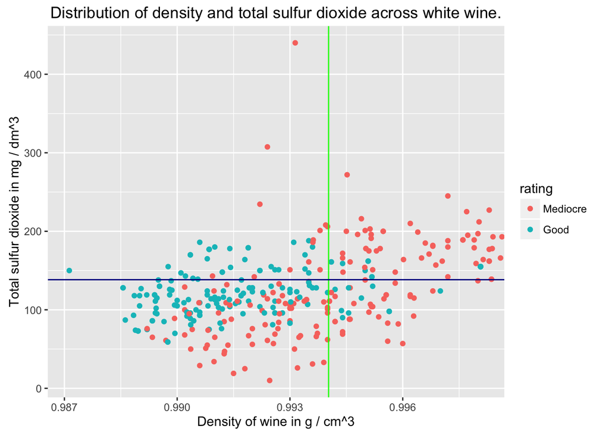

```r
# Density and Total Sulfur Dioxide
ggplot(aes(x = density, y = total.sulfur.dioxide, color = rating),
       data = subset(wv, rating != "Average")) +
  coord_cartesian(xlim = c(quantile(wv$density, 0),
                           quantile(wv$density, 0.9))) +
  geom_point() +
  geom_vline(xintercept = mean(wv$density),
             linetype_pal(3), color = 'green') +
  geom_hline(yintercept = mean(wv$total.sulfur.dioxide),
             linetype_pal(3), color = 'dark blue') +
  xlab('Density of wine in g / cm^3') +
  ylab('Total sulfur dioxide in mg / dm^3') +
  ggtitle('Distribution of density and total sulfur dioxide across white wine.')
```

### Description Two

Good quality wines tend to have a low density and low total sulfur dioxide component in them. Total sulfur dioxide is the amount of free and bound forms of S02; in low concentrations, SO2 is mostly undetectable in wine, but at free SO2 concentrations over 50 ppm, SO2 becomes evident in the nose and taste of wine and is not a preferable quality to have in good wines.

### Plot Three

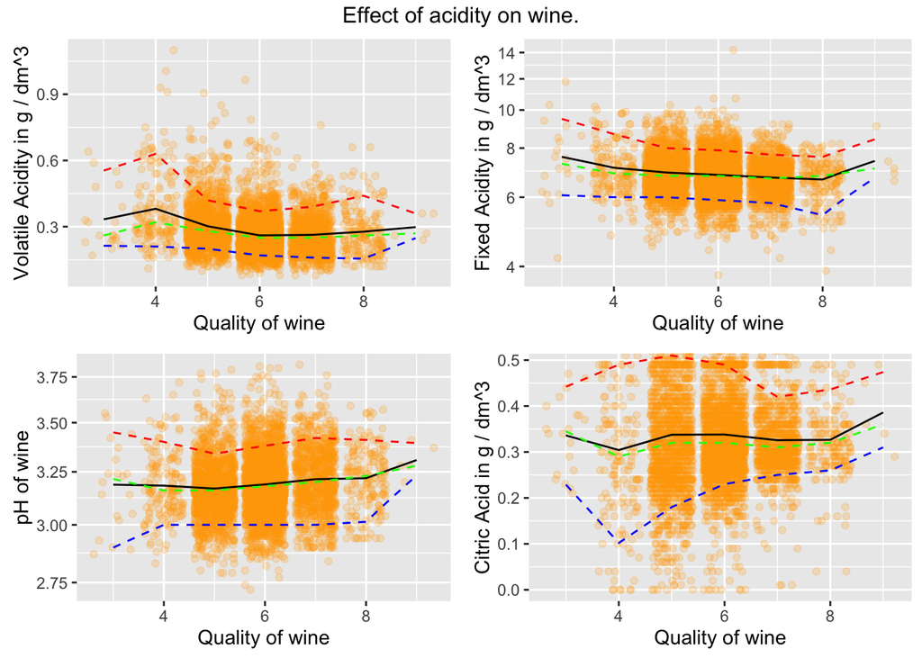

```r
# Acidity in wine

p1 <- ggplot(aes(x = quality, y = volatile.acidity, group =1),
       data = wv) +
      geom_point(alpha = 1/5,
                 position = position_jitter(h = 0),
                 color = 'orange') +
  geom_line(stat = 'summary', fun.y = mean) +
  #generate the 10% quantile on the plot, 10% of wines have volatile.acidity below this line
  geom_line(stat = 'summary', fun.y = quantile, fun.args=list(probs=0.1), linetype = 2, color = 'blue') +
  #90% of wine have volatile.acidity below this line
  geom_line(stat = 'summary', fun.y = quantile, fun.args=list(probs=0.9), linetype = 2, color = 'red') +
  #50% of wine have volatile.acidity below this line
  geom_line(stat = 'summary', fun.y = quantile, fun.args=list(probs=0.5), linetype = 2, color = 'green') +
  xlab('Quality of wine') +
  ylab('Volatile Acidity in g / dm^3')

p2 <- ggplot(aes(x = quality, y = fixed.acidity, group =1),
       data = wv) +
      geom_point(alpha = 1/5,
                 position = position_jitter(h = 0),
                 color = 'orange') +
  coord_trans(y = 'log10') +
  #coord_cartesian(xlim = c(4,8)) +
  geom_line(stat = 'summary', fun.y = mean) +
  #generate the 10% quantile on the plot, 10% of wines have fixed.acidity below this line
  geom_line(stat = 'summary', fun.y = quantile, fun.args=list(probs=0.1), linetype = 2, color = 'blue') +
  #90% of wine have fixed.acidity below this line
  geom_line(stat = 'summary', fun.y = quantile, fun.args=list(probs=0.9), linetype = 2, color = 'red') +
  #50% of wine have fixed.acidity below this line
  geom_line(stat = 'summary', fun.y = quantile, fun.args=list(probs=0.5), linetype = 2, color = 'green') +
  xlab('Quality of wine') +
  ylab('Fixed Acidity in g / dm^3')

p3 <- ggplot(aes(x = quality, y = pH, group =1),
       data = wv) +
      geom_point(alpha = 1/5,
                 position = position_jitter(h = 0),
                 color = 'orange') +
  coord_trans(y = 'log10') +
  #coord_cartesian(xlim = c(4,8)) +
  geom_line(stat = 'summary', fun.y = mean) +
  #generate the 10% quantile on the plot, 10% of wines have pH below this line
  geom_line(stat = 'summary', fun.y = quantile, fun.args=list(probs=0.1), linetype = 2, color = 'blue') +
  #90% of wine have pH below this line
  geom_line(stat = 'summary', fun.y = quantile, fun.args=list(probs=0.9), linetype = 2, color = 'red') +
  #50% of wine have pH below this line
  geom_line(stat = 'summary', fun.y = quantile, fun.args=list(probs=0.5), linetype = 2, color = 'green') +
  xlab('Quality of wine') +
  ylab('pH of wine')

p4 <- ggplot(aes(x = quality, y = citric.acid, group =1),
       data = wv) +
      geom_point(alpha = 1/5,
                 position = position_jitter(h = 0),
                 color = 'orange') +
  coord_cartesian(ylim = c(quantile(wv$citric.acid, 0),
                           quantile(wv$citric.acid, 0.9))) +
  #coord_cartesian(xlim = c(4,8)) +
  geom_line(stat = 'summary', fun.y = mean) +
  #generate the 10% quantile on the plot, 10% of wines have citric acid below this line
  geom_line(stat = 'summary', fun.y = quantile, fun.args=list(probs=0.1), linetype = 2, color = 'blue') +
  #90% of wine have citric acid below this line
  geom_line(stat = 'summary', fun.y = quantile, fun.args=list(probs=0.9), linetype = 2, color = 'red') +
  #50% of wine have citric acid below this line
  geom_line(stat = 'summary', fun.y = quantile, fun.args=list(probs=0.5), linetype = 2, color = 'green') +
  xlab('Quality of wine') +
  ylab('Citric Acid in g / dm^3')

grid.arrange(p1,p2,p3,p4, ncol = 2, top = 'Effect of acidity on wine.')
```

# Reflection

When performing analysis I have come to realise that having an understanding of the underlying data itself plays a key role in extracting useful inferences. In the case of this dataset, having an understanding of the components of wine and what are the key factors that affect the taste of wine as well as their quality was key. I spent some time reading about how wine is made and what are the subtle nuances that go into making different kinds of wine. There were quite a few difficulties I ran into while doing this analysis. For instance I expected acidity to have a much greater affect on the taste of wine than it actually turned out to have. And from that point on I was essentially testing all the other features to understand where correlationns may lie. This is a feesible process when there are a finite number of features such as 12 in this case and can be much harder once the number of features go up. On the other hand, one thing that greatly helped was the pearson r score. This score helped narrow down my analysis greatly and I was able to go deeper into some of the more relevant features.

Being a wine sommelier is a hard task but analysis’ like these can greatly help. I am curious to perform such tests on other spirits like beer and whiskey as well.